# ProFit: Galaxy Fitting Example

Aaron Robotham

2016-05-19

## Prepare the test data

It is worth checking you haev the latest version of `ProFit`:

```r
library(devtools)
install_github('asgr/ProFit')
```

Next we load the libraries we need:

```r
library(knitr)
library(ProFit)
library(FITSio)
```

Next we load a table of data describing GAMA galaxies:

```r
data('ExampleInit', package="ProFit")
kable(head(ExampleInit, 10))
```

| CATAID | sersic.xcen1 | sersic.ycen1 | sersic.mag1 | sersic.mag2 | sersic.re1 | sersic.re2 | sersic.nser1 | sersic.ang2 | sersic.axrat2 |
| --- | --- | --- | --- | --- | --- | --- | --- | --- | --- |
| 265769 | 122.8069 | 87.3328 | 17.08908 | 17.08908 | 8.71420 | 17.4284 | 3.4292 | 105.8498 | 0.1541 |
| 265911 | 84.8832 | 94.5951 | 16.83217 | 16.83217 | 7.05740 | 14.1148 | 4.3776 | 140.8191 | 0.4891 |
| 265940 | 80.3975 | 52.2173 | 18.04857 | 18.04857 | 5.96290 | 11.9258 | 4.6010 | 112.2746 | 0.4875 |
| 265943 | 53.7013 | 83.6956 | 17.70547 | 17.70547 | 6.42060 | 12.8412 | 4.5086 | 168.2385 | 0.4179 |
| 265981 | 148.8727 | 106.4069 | 16.85618 | 16.85618 | 11.00100 | 22.0020 | 2.9434 | 59.6690 | 0.2621 |
| 265986 | 78.1780 | 79.9999 | 18.97747 | 18.97747 | 6.80575 | 13.6115 | 2.0082 | 103.2134 | 0.0423 |
| 265985 | 51.3467 | 73.0023 | 19.03898 | 19.03898 | 5.77065 | 11.5413 | 2.7402 | 0.7028 | 0.5400 |
| 266033 | 66.0826 | 79.0872 | 17.39138 | 17.39138 | 6.25480 | 12.5096 | 4.9178 | 39.5336 | 0.3336 |
| 266035 | 105.1495 | 78.5289 | 18.18017 | 18.18017 | 11.38780 | 22.7756 | 2.9550 | 56.3237 | 0.6222 |
| 266105 | 264.8947 | 219.5667 | 15.45027 | 15.45027 | 36.68265 | 73.3653 | 3.9704 | 94.4409 | 0.3477 |

Now we can extract out the example files we have available for fitting by checking the contents of the directory containing the example FITS files:

```r
ExampleFiles=list.files(paste(.libPaths()[1],'/ProFit/data/',sep=''))
ExampleIDs=unlist(strsplit(ExampleFiles[grep('fitim',ExampleFiles)],'fitim.fits'))
ExampleIDs
```

```
##  [1] "G265911" "G265940" "G266033" "G266035" "G266662" "G267199" "G267489"
##  [8] "G267525" "G278109" "G279148"
```

There are 10 example galaxies included. Here we run example 1:

```r
useID=ExampleIDs[1]
image = readFITS(paste(.libPaths()[1],'/ProFit/data/',useID,'fitim.fits',sep=''))$imDat
mask = readFITS(paste(.libPaths()[1],'/ProFit/data/',useID,'mskim.fits',sep=''))$imDat
sigma = readFITS(paste(.libPaths()[1],'/ProFit/data/',useID,'sigma.fits',sep=''))$imDat
segim = readFITS(paste(.libPaths()[1],'/ProFit/data/',useID,'segim.fits',sep=''))$imDat
psf = readFITS(paste(.libPaths()[1],'/ProFit/data/',useID,'psfim.fits',sep=''))$imDat
```

Next we extract parameters for a very rough model (not meant to look too good yet):

```r
useIDnum=as.integer(strsplit(useID,'G')[[1]][2])
useloc=which(ExampleInit$CATAID==useIDnum)
```

For our initial model we treat component 1 as the putitive bulge and componet 2 as the putitive disk. We are going to attempt a fit where the disk is forced to have nser=1 and the bulge has an axial ratio of 1.

```r
model=list(
  sersic=list(
    xcen= c(ExampleInit$sersic.xcen1[useloc], ExampleInit$sersic.xcen1[useloc]),
    ycen= c(ExampleInit$sersic.ycen1[useloc], ExampleInit$sersic.ycen1[useloc]),
    mag= c(ExampleInit$sersic.mag1[useloc], ExampleInit$sersic.mag2[useloc]),
    re= c(ExampleInit$sersic.re1[useloc], ExampleInit$sersic.re2[useloc]),
    nser= c(ExampleInit$sersic.nser1[useloc], 1),  #Disk is initially nser=1
    ang= c(ExampleInit$sersic.ang2[useloc], ExampleInit$sersic.ang2[useloc]),
    axrat= c(1, ExampleInit$sersic.axrat2[useloc]),
    box=c(0, 0)
  )
)
model
```

```
## $sersic
## $sersic$xcen
## [1] 84.8832 84.8832
##
## $sersic$ycen
## [1] 94.5951 94.5951
##
## $sersic$mag
## [1] 16.83217 16.83217
##
## $sersic$re
## [1]  7.0574 14.1148
##
## $sersic$nser
## [1] 4.3776 1.0000
##
## $sersic$ang
## [1] 140.8191 140.8191
##
## $sersic$axrat
## [1] 1.0000 0.4891
##
## $sersic$box
## [1] 0 0
```

The pure model (no PSF):

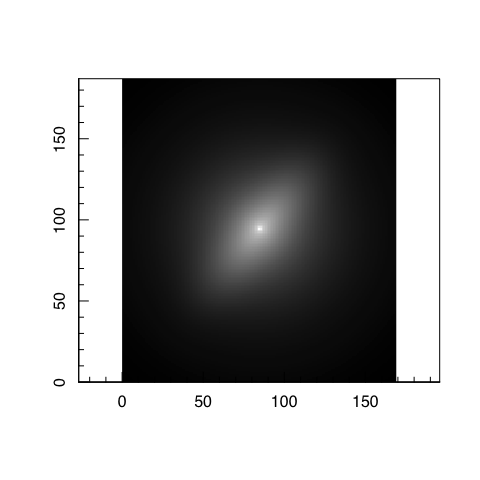

```r
magimage(profitMakeModel(model,dim=dim(image)))
```

The original image:

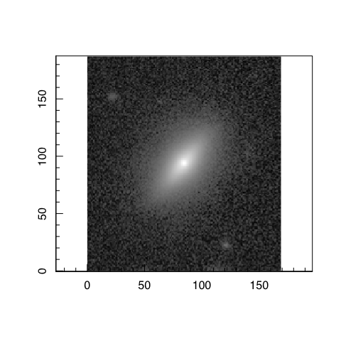

```r
magimage(image)
```

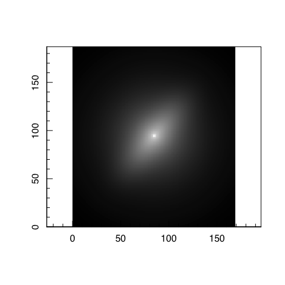

```r
magimage(profitMakeModel(model,dim=dim(image)),psf=psf)
```

Next we define our list of what we want to fit (where TRUE means we will fit it later):

```r
tofit=list(
  sersic=list(
    xcen= c(TRUE,NA), #We fit for xcen and tie the two togther
    ycen= c(TRUE,NA), #We fit for ycen and tie the two togther
    mag= c(TRUE,TRUE), #Fit for both
    re= c(TRUE,TRUE), #Fit for both
    nser= c(TRUE,FALSE), #Fit for bulge
    ang= c(FALSE,TRUE), #Fit for disk
    axrat= c(FALSE,TRUE), #Fit for disk
    box= c(FALSE,FALSE) #Fit for neither
  )
)
```

Now we define what parameters should be fitted in log space:

```r
tolog=list(
  sersic=list(
    xcen= c(FALSE,FALSE),
    ycen= c(FALSE,FALSE),
    mag= c(FALSE,FALSE),
    re= c(TRUE,TRUE), #re is best fit in log space
    nser= c(TRUE,TRUE), #nser is best fit in log space
    ang= c(FALSE,FALSE),
    axrat= c(TRUE,TRUE), #axrat is best fit in log space
    box= c(FALSE,FALSE)
  )
)
```

Now we specify the prior functions. If the parameters are to be sampled in log space (above) then the priors will refer to dex not linear standard deviations. Priors should be specified in their unlogged state- the logging is done internally.

```r
sigmas=c(2,2,2,2,5,5,1,1,1,1,30,30,0.3,0.3,0.3,0.3)

priors=list(
  sersic=list(
    xcen=list(function(x){dnorm(x,0,sigmas[1],log=T)},function(x){dnorm(x,0,sigmas[2],
    log=T)}), # should have tight constraints on x and y
    ycen=list(function(x){dnorm(x,0,sigmas[3],log=T)},function(x){dnorm(x,0,sigmas[4],
    log=T)}), # should have tight constraints on x and y
    mag=list(function(x){dnorm(x,0,sigmas[5],log=T)},function(x){dnorm(x,0,sigmas[6],
    log=T)}), # 5 mag SD
    re=list(function(x){dnorm(x,0,sigmas[7],log=T)},function(x){dnorm(x,0,sigmas[8],
    log=T)}), # i.e. 1 dex in re is the SD
    nser=list(function(x){dnorm(x,0,sigmas[9],log=T)},function(x){dnorm(x,0,sigmas[10],
    log=T)}), # i.e. 1 dex in nser is the SD
    ang=list(function(x){dnorm(x,0,sigmas[11],log=T)},function(x){dnorm(x,0,sigmas[12],
    log=T)}), # very broad 30 deg ang SD
    axrat=list(function(x){dnorm(x,0,sigmas[13],log=T)},function(x){dnorm(x,0,sigmas[14],
    log=T)}), # i.e. 1 dex in axrat is the SD
    box=list(function(x){dnorm(x,0,sigmas[15],log=T)},function(x){dnorm(x,0,sigmas[16],
    log=T)})
  )
)
```

The hard intervals should also be specified in log space if relevant:

```r
lowers=c(0,0,0,0,10,10,0,0,-1,-1,-180,-180,-1,-1,-1,-1)
uppers=c(1e3,1e3,1e3,1e3,30,30,2,2,1.3,1.3,360,360,0,0,1,1)

intervals=list(
  sersic=list(
    xcen=list(function(x){interval(x,lowers[1],uppers[1],reflect=F)},
    function(x){interval(x,lowers[2],uppers[2],reflect=F)}),
    ycen=list(function(x){interval(x,lowers[3],uppers[3],reflect=F)},
    function(x){interval(x,lowers[4],uppers[4],reflect=F)}),
    mag=list(function(x){interval(x,lowers[5],uppers[5],reflect=F)},
    function(x){interval(x,lowers[6],uppers[6],reflect=F)}),
    re=list(function(x){interval(x,lowers[7],uppers[7],reflect=F)},
    function(x){interval(x,lowers[8],uppers[8],reflect=F)}),
    nser=list(function(x){interval(x,lowers[9],uppers[9],reflect=F)},
    function(x){interval(x,lowers[10],uppers[10],reflect=F)}),
    ang=list(function(x){interval(x,lowers[11],uppers[11],reflect=F)},
    function(x){interval(x,lowers[12],uppers[12],reflect=F)}),
    axrat=list(function(x){interval(x,lowers[13],uppers[13],reflect=F)},
    function(x){interval(x,lowers[14],uppers[14],reflect=F)}),
    box=list(function(x){interval(x,lowers[15],uppers[15],reflect=F)},
    function(x){interval(x,lowers[16],uppers[16],reflect=F)})
  )
)
```

Setup the data structure we need for optimisation:

```r
Data=profitSetupData(image=image, mask=mask, sigma=sigma, segim=segim, psf=psf,
model=model, tofit=tofit, tolog=tolog, priors=priors, intervals=intervals,
magzero=0, algo.func='optim', verbose=TRUE)
```

This produces a fairly complex R object, but with all the bits we need for fitting, e.g. (notice the tolog parameteres are now logged):

```r
Data$init
```

```
##  sersic.xcen1  sersic.ycen1   sersic.mag1   sersic.mag2    sersic.re1
##    84.8832000    94.5951000    16.8321750    16.8321750     0.8486447
##    sersic.re2  sersic.nser1   sersic.ang2 sersic.axrat2
##     1.1496747     0.6412361   140.8191000    -0.3106023
```

These are the parameters we wish to fit for, and we take the initial guesses from the model list we provided before.

We can test how things currently look (we get an output because we set verbose=TRUE earlier):

```
## $sersic
## $sersic$xcen
## [1] 84.8832 84.8832
##
## $sersic$ycen
## [1] 94.5951 94.5951
##
## $sersic$mag
## [1] 16.83217 16.83217
##
## $sersic$re
## [1]  7.0574 14.1148
##
## $sersic$nser
## [1] 4.3776 1.0000
##
## $sersic$ang
## [1] 140.8191 140.8191
##
## $sersic$axrat
## [1] 1.0000 0.4891
##
## $sersic$box
## [1] 0 0
```

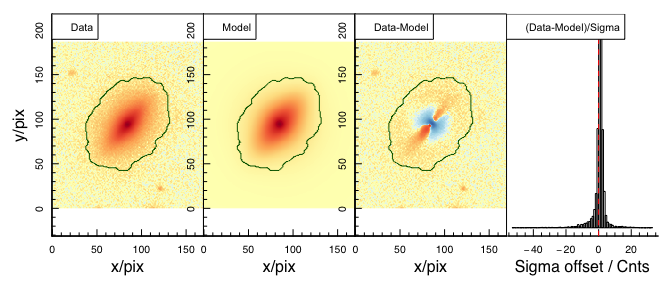

```
##  sersic.xcen1  sersic.ycen1   sersic.mag1   sersic.mag2    sersic.re1
##  8.488320e+01  9.459510e+01  1.683217e+01  1.683217e+01  8.486447e-01
##    sersic.re2  sersic.nser1   sersic.ang2 sersic.axrat2
##  1.149675e+00  6.412361e-01  1.408191e+02 -3.106023e-01 -1.852528e+04
```

```r
profitLikeModel(parm=Data$init, Data=Data, image=TRUE)
```

## Do some fitting

First try `optim` BFGS:

```r
optimfit=optim(Data$init, profitLikeModel, method='L-BFGS-B', Data=Data, rough=TRUE,
lower=lowers[which(unlist(tofit))], upper=uppers[which(unlist(tofit))],
control=list(fnscale=-1,parscale=sigmas[which(unlist(tofit))]))
```

The best `optim` BFGS fit is given by:

```r
optimfit$par
```

[output not shown]

Check it out:

```r
profitLikeModel(optimfit$par,Data,image=TRUE,serscomp=1)
profitLikeModel(optimfit$par,Data,image=TRUE,serscomp=2)
profitLikeModel(optimfit$par,Data,image=TRUE,serscomp='all')
```

[output not shown]

Now we can try a `LaplaceApproximation` fit (should take a few minutes):

```r
library(LaplacesDemon)
Data$algo.func = "LA"
LAfit=LaplaceApproximation(profitLikeModel, parm=Data$init, Data=Data, Iterations=1e4,
Method='BFGS', CovEst='Identity', sir=FALSE)
```

The best LA BFGS fit is given by:

```r
LAfit$Summary1[,1]
```

[output not shown]

Check it out:

```r
profitLikeModel(LAfit$Summary1[,1],Data,image=TRUE,serscomp=1)
profitLikeModel(LAfit$Summary1[,1],Data,image=TRUE,serscomp=2)
profitLikeModel(LAfit$Summary1[,1],Data,image=TRUE,serscomp='all')
```

[output not shown]

Now we can try a `LaplacesDemon` fit:

```r
Data$algo.func = "LD"

LDfit=LaplacesDemon(profitLikeModel, Initial.Values=optimfit$par, Data=Data,
Iterations=1e4, Algorithm='CHARM', Thinning=1, Specs=list(alpha.star=0.44))
```

If it has converged well you will have a Summary2 structure using the ESS:

```r
LDfit$Summary2
```

[output not shown]

If not you can still check Summary1:

```r
LDfit$Summary1
```

[output not shown]

With any luck you have enough stationary samples to run:

```r
BestLD=magtri(LDfit$Posterior2)
```

Otherwise try:

```r
BestLD=magtri(LDfit$Posterior1,500)
```

We can now check our final fit:

```r
profitLikeModel(BestLD,Data,image=TRUE,serscomp=1)
profitLikeModel(BestLD,Data,image=TRUE,serscomp=2)
profitLikeModel(BestLD,Data,image=TRUE,serscomp='all')
```

[output not shown]